# Project

Lucas Villalba

2024-01-13

# Capstone Project

## Part of Google Data Analytics profesional certificate

Working on how the Garmin personal database(could be any other brand) can help us throughout exams at the third level education with a healthy body equals to a healthy mind,

The dataset the physical activities, habits, and routines of a male age 39 ~ 42 years old, from 2018 to 2022.

How a mature student can cope throughout exams at third level education and success with a good health and fitness, ‘mens sana in corpore sano’

Also, it enhances our readiness for a future successful professional life after finishing our studies.

- The methodology going through the Ask, Prepare, Process, Analyze, and Share phases of the data analysis process.

# Five questions:

1. What type of company does your client represent, and what are they asking you to accomplish?

Personal interest in how I can cope with stress during exams

2. What are the key factors involved in the business task you are investigating?

Tracking my physical activity during the 4 (four) years, the same time period which took to completed my course.

3. What type of data will be appropriate for your analysis?

All my physical activities during the time from 2018 to 2022.

4. Where will you obtain that data?

The data obtained from Garmin personal fitness database, downloaded via Garmin website from 2018 to 2022.

5. Who is your audience, and what materials will help you present to them effectively?

My audience a mature male group range age from 38 years old to 42 years old, who are attending a full time course, working part time and in a professional growth path.

*Stating a business task clearly.*

**How a healthy physical activity routine helps us to cope with stress during exams.**

```r
options(repos = c(CRAN = "https://cran.rstudio.com/"))
install.packages("tidyverse")
```

- Importing data from a real dataset.

```r
activities_df <-
  read.csv("C:/Users/Administrador/OneDrive/Documentos/R/ABDA/Report/Activities.csv")
str(activities_df)
```

```
## 'data.frame':    854 obs. of  42 variables:
##  $ Activity.Type           : chr  "Pilates" "Pool Swimming" "Cycling" "Pilates" ...
##  $ Date                    : chr  "2022-02-16 09:19:44" "2022-02-15 19:37:14" "2022-02-15 13:16:40" "2022-02-15 08:50:39" ...
##  $ Favorite                : chr  "false" "false" "false" "false" ...
##  $ Title                   : chr  "Pilates" "Pool Swimming" "County Dublin Cycling" "Pilates" ...
##  $ Distance                : chr  "0.00" "1,300" "6.08" "0.00" ...
##  $ Calories                : chr  "16" "276" "346" "9" ...
##  $ Time                    : chr  "00:02:31.0" "00:36:21" "00:43:22" "00:02:03.0" ...
##  $ Avg.HR                  : chr  "103" "151" "124" "88" ...
##  $ Max.HR                  : chr  "119" "197" "154" "102" ...
##  $ Avg.Run.Cadence         : chr  "--" "--" "--" "--" ...
##  $ Max.Run.Cadence         : chr  "--" "--" "--" "--" ...
##  $ Avg.Speed               : chr  "--" "2:09" "8.4" "--" ...
##  $ Max.Speed               : chr  "--" "0:41" "36.3" "--" ...
##  $ Total.Ascent            : chr  "--" "--" "23" "--" ...
```

[output cut: 28 more lines]

- Documenting any data cleaning that you perform on the data set.

```r
install.packages("tidyverse")
install.packages("skimr")
install.packages("janitor")
library(tidyverse)
library(skimr)
library(janitor)
```

- Quick visualization of the raw data.

[figure not shown]

```r
ggplot(data = activities_df) +
  geom_point(mapping = aes(x = Activity.Type, y = Calories, color = Activity.Type)) +
  labs(title = "All the activities by Calories") +
  theme(axis.text.x = element_text(angle = 45))
```

# Prepare

- Where is your data located? The Data is located in a sub-folder no related to the project, for this reason is good to save the data in the following path “R/Coursera/Project” this is part of good habits data structure

```r
write.csv(activities_df, file = "~/R/Coursera/Project/activities.csv", na = "NA")
```

- How is the data organized? Data frame is organized in rows and columns, with 854 observations (rows) and 42 variables (columns), each observation is a physical activity with variables like:

```r
colnames(activities_df)
```

```
##  [1] "Activity.Type"            "Date"
##  [3] "Favorite"                 "Title"
##  [5] "Distance"                 "Calories"
##  [7] "Time"                     "Avg.HR"
##  [9] "Max.HR"                   "Avg.Run.Cadence"
## [11] "Max.Run.Cadence"          "Avg.Speed"
## [13] "Max.Speed"                "Total.Ascent"
## [15] "Total.Descent"            "Avg.Stride.Length"
## [17] "Avg.Vertical.Ratio"       "Avg.Vertical.Oscillation"
## [19] "Training.Stress.Score."   "Grit"
## [21] "Flow"                     "Total.Strokes"
## [23] "Avg..Swolf"               "Avg.Stroke.Rate"
## [25] "Dive.Time"                "Min.Temp"
## [27] "Surface.Interval"         "Decompression"
## [29] "Best.Lap.Time"            "Number.of.Laps"
## [31] "Max.Temp"                 "Avg.Resp"
## [33] "Min.Resp"                 "Max.Resp"
## [35] "Stress.Change"            "Stress.Start"
## [37] "Stress.End"               "Avg.Stress"
## [39] "Moving.Time"              "Elapsed.Time"
## [41] "Min.Elevation"            "Max.Elevation"
```

```r
skim_without_charts(activities_df)
```

Data summary

| Name | activities_df |
| --- | --- |
| Number of rows | 854 |
| Number of columns | 42 |
| _______________________ |  |
| Column type frequency: |  |
| character | 33 |
| numeric | 9 |
| ________________________ |  |
| Group variables | None |

**Variable type: character**

| skim_variable | n_missing | complete_rate | min | max | empty | n_unique | whitespace |
| --- | --- | --- | --- | --- | --- | --- | --- |
| Activity.Type | 0 | 1 | 4 | 17 | 0 | 12 | 0 |
| Date | 0 | 1 | 19 | 19 | 0 | 854 | 0 |
| Favorite | 0 | 1 | 4 | 5 | 0 | 2 | 0 |
| Title | 0 | 1 | 3 | 26 | 0 | 24 | 0 |
| Distance | 0 | 1 | 2 | 5 | 0 | 296 | 0 |
| Calories | 0 | 1 | 1 | 5 | 0 | 334 | 0 |
| Time | 0 | 1 | 8 | 10 | 0 | 675 | 0 |
| Avg.HR | 0 | 1 | 2 | 3 | 0 | 108 | 0 |
| Max.HR | 0 | 1 | 2 | 3 | 0 | 119 | 0 |
| Avg.Run.Cadence | 0 | 1 | 1 | 3 | 0 | 36 | 0 |
| Max.Run.Cadence | 0 | 1 | 2 | 3 | 0 | 55 | 0 |
| Avg.Speed | 0 | 1 | 2 | 5 | 0 | 236 | 0 |
| Max.Speed | 0 | 1 | 2 | 5 | 0 | 289 | 0 |
| Total.Ascent | 0 | 1 | 1 | 5 | 0 | 81 | 0 |
| Total.Descent | 0 | 1 | 1 | 5 | 0 | 75 | 0 |
| Total.Strokes | 0 | 1 | 2 | 3 | 0 | 9 | 0 |
| Avg..Swolf | 0 | 1 | 2 | 2 | 0 | 8 | 0 |
| Avg.Stroke.Rate | 0 | 1 | 2 | 2 | 0 | 5 | 0 |
| Dive.Time | 0 | 1 | 4 | 4 | 0 | 1 | 0 |
| Surface.Interval | 0 | 1 | 4 | 4 | 0 | 1 | 0 |
| Decompression | 0 | 1 | 2 | 2 | 0 | 1 | 0 |
| Best.Lap.Time | 0 | 1 | 8 | 11 | 0 | 548 | 0 |
| Avg.Resp | 0 | 1 | 2 | 2 | 0 | 5 | 0 |
| Min.Resp | 0 | 1 | 2 | 2 | 0 | 2 | 0 |
| Max.Resp | 0 | 1 | 2 | 2 | 0 | 6 | 0 |
| Stress.Change | 0 | 1 | 1 | 2 | 0 | 9 | 0 |
| Stress.Start | 0 | 1 | 2 | 2 | 0 | 8 | 0 |
| Stress.End | 0 | 1 | 2 | 2 | 0 | 5 | 0 |
| Avg.Stress | 0 | 1 | 2 | 2 | 0 | 9 | 0 |
| Moving.Time | 0 | 1 | 8 | 10 | 0 | 440 | 0 |
| Elapsed.Time | 0 | 1 | 8 | 10 | 0 | 678 | 0 |
| Min.Elevation | 0 | 1 | 1 | 2 | 0 | 41 | 0 |
| Max.Elevation | 0 | 1 | 1 | 3 | 0 | 43 | 0 |

**Variable type: numeric**

| skim_variable | n_missing | complete_rate | mean | sd | p0 | p25 | p50 | p75 | p100 |
| --- | --- | --- | --- | --- | --- | --- | --- | --- | --- |
| Avg.Stride.Length | 0 | 1 | 0.31 | 0.67 | 0 | 0 | 0.13 | 0.42 | 16.72 |
| Avg.Vertical.Ratio | 0 | 1 | 0.00 | 0.00 | 0 | 0 | 0.00 | 0.00 | 0.00 |
| Avg.Vertical.Oscillation | 0 | 1 | 0.00 | 0.00 | 0 | 0 | 0.00 | 0.00 | 0.00 |
| Training.Stress.Score. | 0 | 1 | 0.00 | 0.00 | 0 | 0 | 0.00 | 0.00 | 0.00 |
| Grit | 0 | 1 | 0.00 | 0.00 | 0 | 0 | 0.00 | 0.00 | 0.00 |
| Flow | 0 | 1 | 0.00 | 0.00 | 0 | 0 | 0.00 | 0.00 | 0.00 |
| Min.Temp | 0 | 1 | 0.00 | 0.00 | 0 | 0 | 0.00 | 0.00 | 0.00 |
| Number.of.Laps | 0 | 1 | 2.42 | 3.73 | 1 | 1 | 1.00 | 2.00 | 46.00 |
| Max.Temp | 0 | 1 | 0.00 | 0.00 | 0 | 0 | 0.00 | 0.00 | 0.00 |

Key tasks

- Download data and store it appropriately.
- Identify how it’s organized.
- Sort and filter the data.
- Determine the credibility of the data.

Deliverable

- A description of all data sources used

# Process

- What tools are you choosing and why? I am choosing RStudio RStudio 2023.12.0 Build 369 © 2009-2023 Posit Software, PBC I find it more efficient for data visualization, cleaning and data wrangling, all with a same document in RMarkdown.
- Have you ensured your data’s integrity? The source of the data is trusted.
- What steps have you taken to ensure that your data is clean? Data cleaning steps:

```r
# Select the variables for the analysis.
trimmed_activities_2018_2022<-activities_df %>%
  select(Activity.Type, Date, Calories, Avg.HR, Avg.Stress)

# Check the data type of the variables.
str(trimmed_activities_2018_2022$Date)
```

```
##  chr [1:854] "2022-02-16 09:19:44" "2022-02-15 19:37:14" ...
```

```r
# Change the variable Date (character type) to date(date type) .
trimmed_activities_2018_2022$date <- as.Date(trimmed_activities_2018_2022$Date)

# Change the variable Calories(character type) to calories(numeric type).
trimmed_activities_2018_2022$calories <- as.numeric(trimmed_activities_2018_2022$Calories)
# Change the variable Avg.HR (character type) to avg_hr (numeric type).
trimmed_activities_2018_2022$avg_hr <- as.numeric(trimmed_activities_2018_2022$Avg.HR)
# Change the variable Avg.Stress (character type) to avg_stress (numeric type).
trimmed_activities_2018_2022$avg_stress <- as.numeric(trimmed_activities_2018_2022$Avg.Stress)
# Change the variable name Activity.Type to act_type and delet from the data frame.
trimmed_activities_2018_2022 <- trimmed_activities_2018_2022 %>%
  mutate(act_type = Activity.Type) %>%
  select(-Activity.Type)

# finally select the new order for the variables for analysis.
act_2018_2022 <- trimmed_activities_2018_2022 %>%
  select(act_type, date, avg_stress, avg_hr, calories)
act_2018_2022$date <- as.Date(act_2018_2022$date)
class(act_2018_2022$date)
```

```
## [1] "Date"
```

- How can you verify that your data is clean and ready to analyze? Check data structure.

```r
# Overview of the data frame
str(act_2018_2022)
```

```
## 'data.frame':    854 obs. of  5 variables:
##  $ act_type  : chr  "Pilates" "Pool Swimming" "Cycling" "Pilates" ...
##  $ date      : Date, format: "2022-02-16" "2022-02-15" ...
##  $ avg_stress: num  NA NA NA NA NA NA 83 NA 84 NA ...
##  $ avg_hr    : num  103 151 124 88 124 162 106 147 95 93 ...
##  $ calories  : num  16 276 346 9 192 536 14 135 10 11 ...
```

```r
colnames(act_2018_2022)
```

```
## [1] "act_type"   "date"       "avg_stress" "avg_hr"     "calories"
```

```r
skim_without_charts(act_2018_2022)
```

Data summary

| Name | act_2018_2022 |
| --- | --- |
| Number of rows | 854 |
| Number of columns | 5 |
| _______________________ |  |
| Column type frequency: |  |
| character | 1 |
| Date | 1 |
| numeric | 3 |
| ________________________ |  |
| Group variables | None |

**Variable type: character**

| skim_variable | n_missing | complete_rate | min | max | empty | n_unique | whitespace |
| --- | --- | --- | --- | --- | --- | --- | --- |
| act_type | 0 | 1 | 4 | 17 | 0 | 12 | 0 |

**Variable type: Date**

| skim_variable | n_missing | complete_rate | min | max | median | n_unique |
| --- | --- | --- | --- | --- | --- | --- |
| date | 0 | 1 | 2017-12-18 | 2022-02-16 | 2020-11-18 | 546 |

**Variable type: numeric**

| skim_variable | n_missing | complete_rate | mean | sd | p0 | p25 | p50 | p75 | p100 |
| --- | --- | --- | --- | --- | --- | --- | --- | --- | --- |
| avg_stress | 846 | 0.01 | 77.50 | 15.55 | 53 | 68.25 | 83.5 | 86 | 97 |
| avg_hr | 63 | 0.93 | 116.96 | 26.88 | 46 | 94.00 | 113.0 | 137 | 174 |
| calories | 35 | 0.96 | 172.72 | 213.16 | 1 | 22.00 | 41.0 | 332 | 974 |

```r
# dealing with missing values
# the device(forerunner 35) does not read stress so for three first year was no data, so we can see a small data set with out NA or missing values, decided to keep the NA and using calories variable.
drop_na(act_2018_2022)
```

```
##   act_type       date avg_stress avg_hr calories
## 1     Yoga 2022-02-14         83    106       14
## 2     Yoga 2022-02-12         84     95       10
## 3     Yoga 2022-02-04         72     95       10
## 4     Yoga 2022-02-02         97    111       15
## 5     Yoga 2022-01-31         53     84        6
## 6     Yoga 2022-01-28         57     86        4
## 7     Yoga 2022-01-26         89    104       13
## 8     Yoga 2022-01-24         85    104       13
```

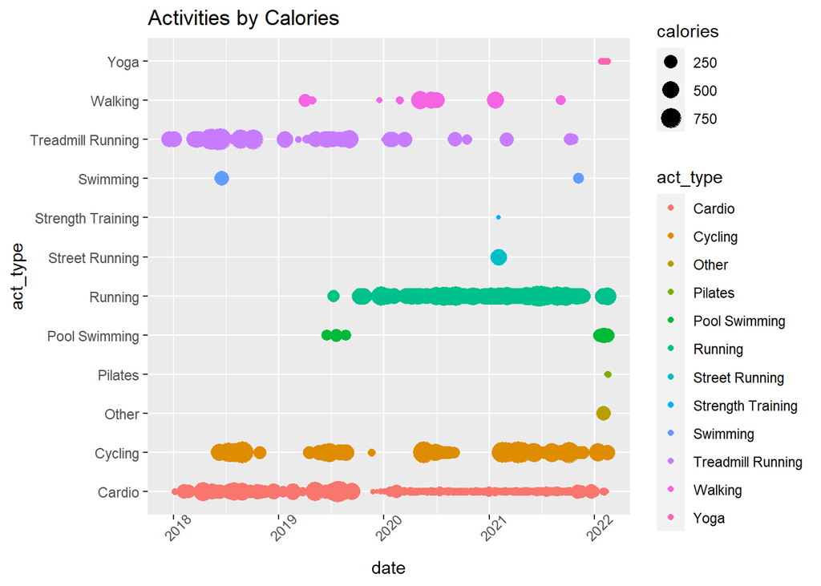

```r
# Data visualization of the data cleaning results
ggplot(data = act_2018_2022) +
  geom_point(mapping = aes(x = date, y = act_type, color = act_type, size = calories)) +
  labs(title = "Activities by Calories") +
  theme(axis.text.x = element_text(angle = 45))
```

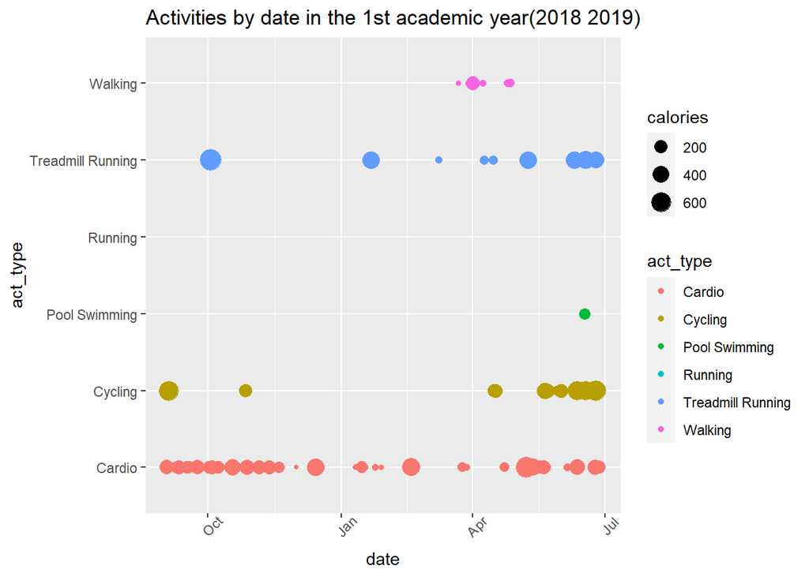

```r
# Data manipulation, group the data by academic calendar year as following:

# Calendar year from Sept 2018 to Jun 2019
act_2018_2019 <- act_2018_2022[act_2018_2022$date > "2018-09-01" & act_2018_2022$date < "2019-06-30",]

# Calendar year from Sept 2019 to Jun 2020
act_2019_2020 <- act_2018_2022[act_2018_2022$date > "2019-09-01" & act_2018_2022$date < "2020-06-30",]

# Calendar year from Sept 2020 to Jun 2021
act_2020_2021 <- act_2018_2022[act_2018_2022$date > "2020-09-01" & act_2018_2022$date < "2021-06-30",]

# Calendar year from Sept 2021 to Jun 2022
act_2021_2022 <- act_2018_2022[act_2018_2022$date > "2021-09-01" & act_2018_2022$date < "2022-06-30",]

# Visualizations by academic year
# Activities 1st year 2018 2019
ggplot(data = act_2018_2019) +
  geom_point(mapping = aes(x = date, y = act_type, color = act_type, size = calories)) +
  labs(title = "Activities by date in the 1st academic year(2018 2019)") +
  theme(axis.text.x = element_text(angle = 45))
```

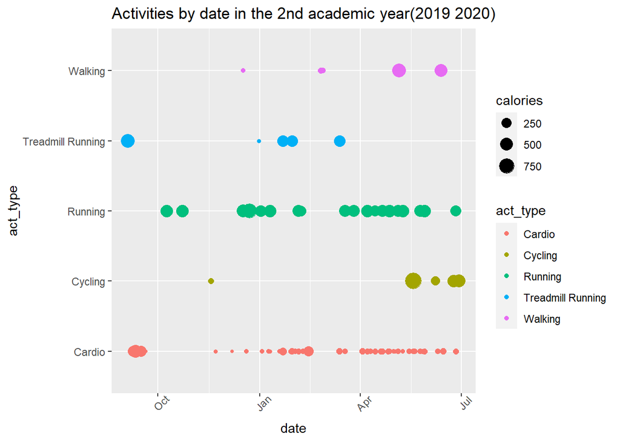

```r
# Activities 2nd year 2019 2020
ggplot(data = act_2019_2020) +
  geom_point(mapping = aes(x = date, y = act_type, color = act_type, size = calories)) +
  labs(title = "Activities by date in the 2nd academic year(2019 2020)")+
  theme(axis.text.x = element_text(angle = 45))
```

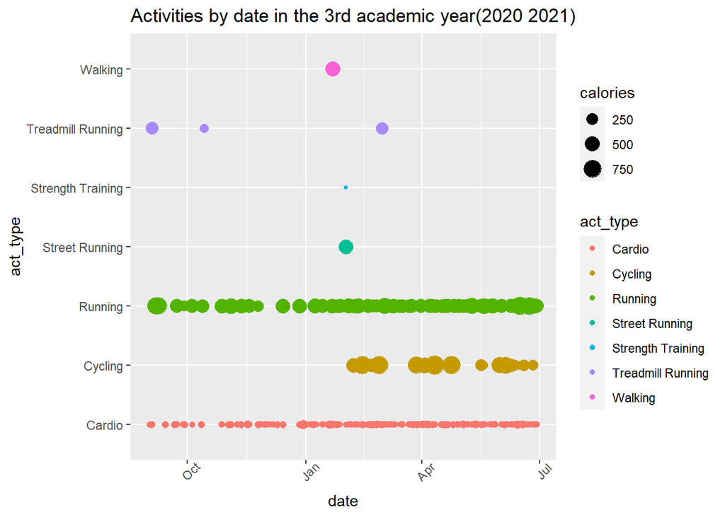

```r
# Activities 3rd year 2020 2021
ggplot(data = act_2020_2021) +
  geom_point(mapping = aes(x = date, y = act_type, color = act_type, size = calories)) +
  labs(title = "Activities by date in the 3rd academic year(2020 2021)") +
  theme(axis.text.x = element_text(angle = 45))
```

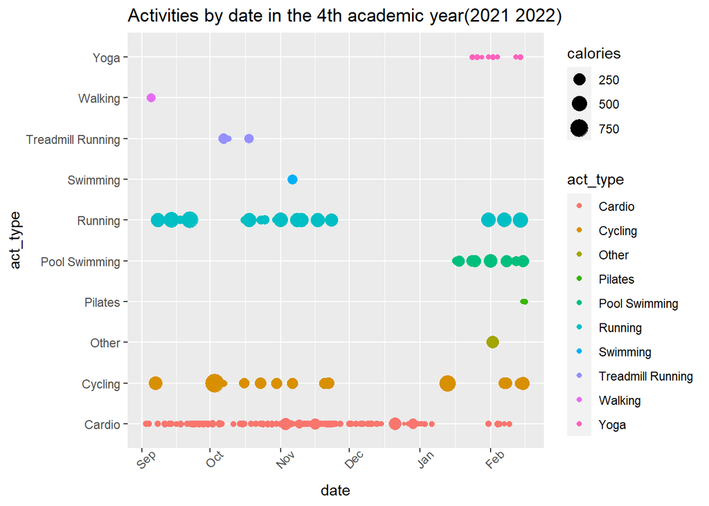

```r
# Activities 4th year 2021 2022
ggplot(data = act_2021_2022) +
  geom_point(mapping = aes(x = date, y = act_type, color = act_type, size = calories)) +
  labs(title = "Activities by date in the 4th academic year(2021 2022)") +
  theme(axis.text.x = element_text(angle = 45))
```

Deliverable Documentation of any cleaning or manipulation of data

# Analyze

- Analyzing the data with visualizations year by year.
- Creating data visualizations from your analysis.

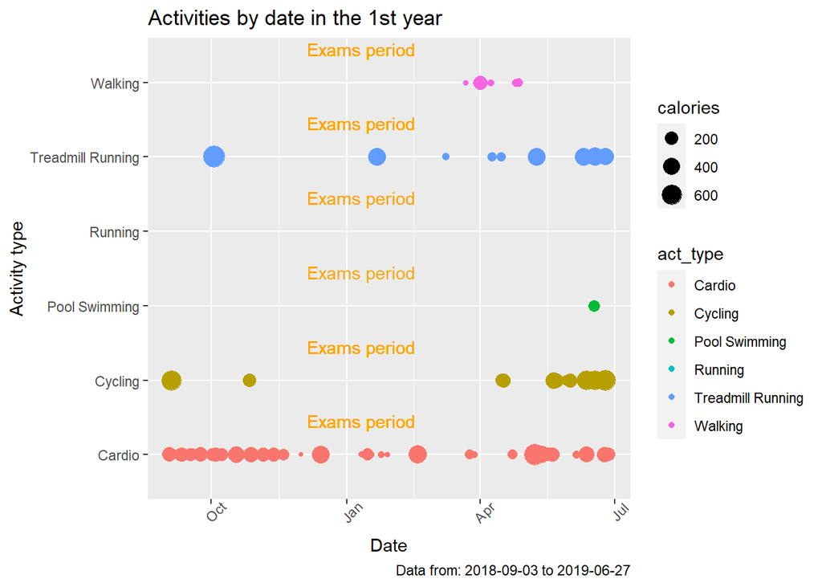

```r
# Calculate the start date and the finish date
min_d_2018<-min(act_2018_2019$date)
max_d_2019<-max(act_2018_2019$date)

# Visualization of the year with date and exams period
p<-ggplot(data = act_2018_2019) +
  geom_point(mapping = aes(x = date, y = act_type, color = act_type, size = calories)) +
  labs(title = "Activities by date in the 1st year", caption=paste0("Data from: ", min_d_2018, " to ", max_d_2019), x = "Date", y = "Activity type") +
  theme(axis.text.x = element_text(angle = 45))

# adding the exams period
p + annotate(geom = "text", x = as.Date("2019-01-11"), y =(act_2018_2019$act_type), label = "Exams period", vjust = -2, color = "orange")
```

## 1st year

For the first year, the exam period was predicted in January, no repeating exams period as was not re-sitting. **“Exams period”** shows the lack of physical activity and this trigger stress as new physical activities were in place after the exams period, as *walking*.

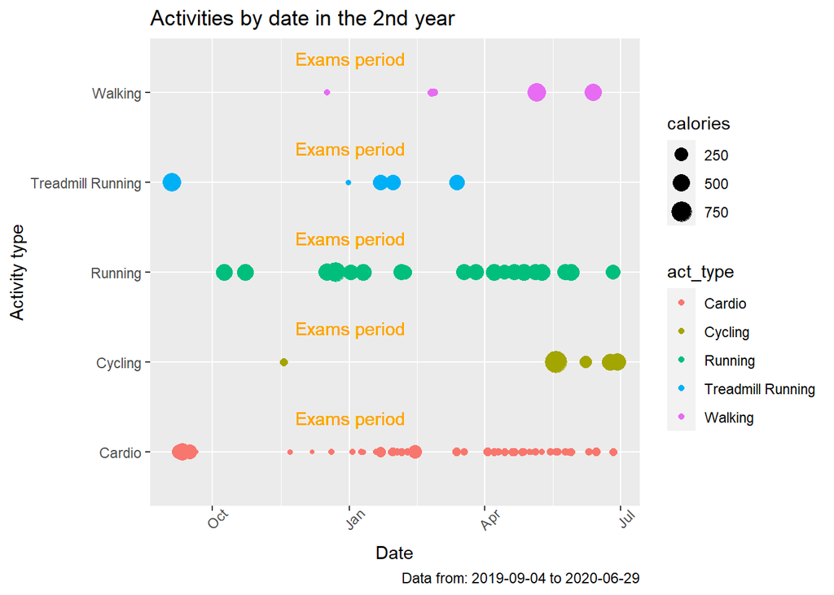

```r
# Calculate the start date and the finish date
min_d_2019<-min(act_2019_2020$date)
max_d_2020<-max(act_2019_2020$date)

# Visualization of the year with date and exams period
p<-ggplot(data = act_2019_2020) +
  geom_point(mapping = aes(x = date, y = act_type, color = act_type, size = calories)) +
  labs(title = "Activities by date in the 2nd year", caption=paste0("Data from: ", min_d_2019, " to ", max_d_2020), x = "Date", y = "Activity type") +
  theme(axis.text.x = element_text(angle = 45))

# adding the exams period
p + annotate(geom = "text", x = as.Date("2020-01-02"), y =(act_2019_2020$act_type), label = "Exams period", vjust = -2, color = "orange")
```

## 2nd year

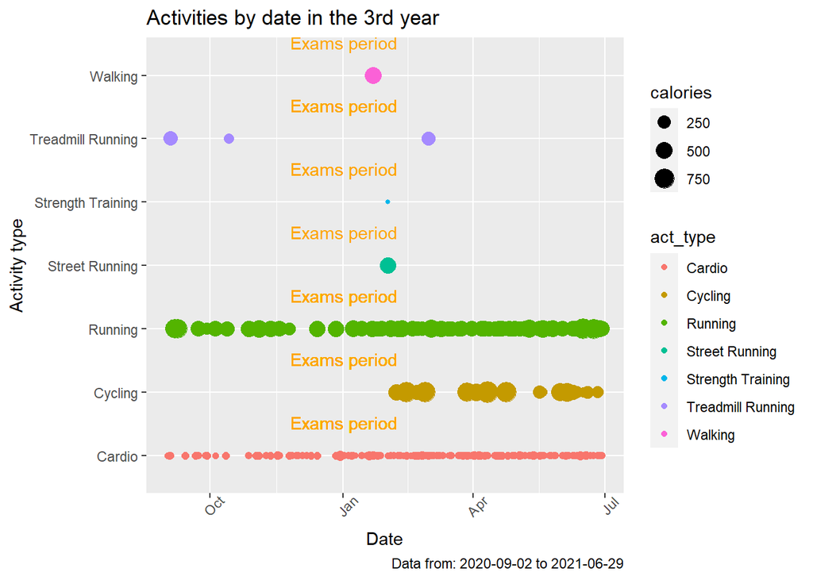

```r
# Calculate the start date and the finish date
min_d_2020<-min(act_2020_2021$date)
max_d_2021<-max(act_2020_2021$date)

# Visualization of the year with date and exams period
p<-ggplot(data = act_2020_2021) +
  geom_point(mapping = aes(x = date, y = act_type, color = act_type, size = calories)) +
  labs(title = "Activities by date in the 3rd year", caption=paste0("Data from: ", min_d_2020, " to ", max_d_2021), x = "Date", y = "Activity type") +
  theme(axis.text.x = element_text(angle = 45))

# adding the exams period
p + annotate(geom = "text", x = as.Date("2021-01-02"), y =(act_2020_2021$act_type), label = "Exams period", vjust = -2, color = "orange")
```

## 3rd year

For the third year, the exam period was predicted in January, no repeating exams period as was not re-sitting. **“Exams period”** shows the continuity of physical activity, this keep calories consumption levels, and new physical activities were in place at the end of exams period, as *Street Running* and *Strength training*.

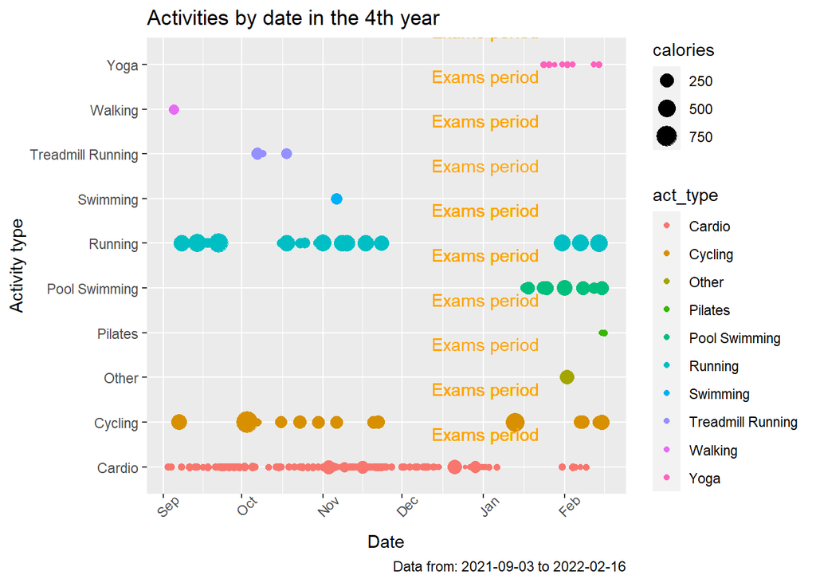

```r
# Calculate the start date and the finish date
min_d_2021<-min(act_2021_2022$date)
max_d_2022<-max(act_2021_2022$date)

# Visualization of the year with date and exams period
p<-ggplot(data = act_2021_2022) +
  geom_point(mapping = aes(x = date, y = act_type, color = act_type, size = calories)) +
  labs(title = "Activities by date in the 4th year", caption=paste0("Data from: ", min_d_2021, " to ", max_d_2022), x = "Date", y = "Activity type") +
  theme(axis.text.x = element_text(angle = 45))

# adding the exams period
p + annotate(geom = "text", x = as.Date("2022-01-02"), y =(act_2021_2022$act_type), label = "Exams period", vjust = -2, color = "orange")
```

## 4th year

For the fourth year, the exam period was predicted in January, no repeating exams period as was not re-sitting. **“Exams period”** shows a decrease of physical activity, a high stress post exams period and a new physical activities added in place after the exams period, as *Yoga* and *Pilates*.

## Final Conclusion:

- Summarizing key findings from your analysis.
- Documenting your conclusions and recommendations.
- Creating and publishing your case study.

Deliverable: 1. A clear statement of the business task you have selected to investigate 2. A description of all data sources used 3. Documentation of any cleaning or manipulation of data 4. A summary of your analysis 5. Supporting visualizations and key findings 6. Based on what you discover, a list of additional deliverables you think would be helpful to include for further exploration 7. Your top high-level insights based on your analysis